# Decision Trees - Encanto - Save Luisa - Part 2

## Loading packages

```r
library("rpart")
library("tidyverse")
library("rpart.plot")
```

## Load dataset

```r
data <- read.csv("save luisa.csv")
head(data)
```

|  | Age | Favourite_healthy_food | Favourite_cheat_meal | Main_macronutrient_source | Flexibility_level | Dehydration | Compound_movements_workout | Workout_minutes_per_week | Outcome |
| --- | --- | --- | --- | --- | --- | --- | --- | --- | --- |
| 1 | 18 | Kale | Pizza | Bad fat | 108 | no | no | 167 | Strength_restored |
| 2 | 18 | Kale | Pizza | Carbs | 608 | no | no | 267 | Strength_restored |
| 3 | 18 | Kale | Pizza | Bad fat | 108 | no | no | 169 | Strength_restored |
| 4 | 18 | Kale | Pizza | Carbs | 608 | no | no | 210 | Strength_restored |
| 5 | 18 | Kale | Pizza | Bad fat | 108 | no | no | 92 | Strength_restored |
| 6 | 18 | Kale | Pizza | Bad fat | 348 | no | no | 443 | Strength_restored |

```r
glimpse(data)
```

```
## Rows: 11,162
## Columns: 9
## $ Age                        <int> 18, 18, 18, 18, 18, 18, 18, 18, 19, 19, 19,…
## $ Favourite_healthy_food     <chr> "Kale", "Kale", "Kale", "Kale", "Kale", "Ka…
## $ Favourite_cheat_meal       <chr> "Pizza", "Pizza", "Pizza", "Pizza", "Pizza"…
## $ Main_macronutrient_source  <chr> "Bad fat", "Carbs", "Bad fat", "Carbs", "Ba…
## $ Flexibility_level          <int> 108, 608, 108, 608, 108, 348, 3, 5, 134, 10…
## $ Dehydration                <chr> "no", "no", "no", "no", "no", "no", "no", "…
## $ Compound_movements_workout <chr> "no", "no", "no", "no", "no", "no", "no", "…
## $ Workout_minutes_per_week   <int> 167, 267, 169, 210, 92, 443, 130, 143, 271,…
## $ Outcome                    <chr> "Strength_restored", "Strength_restored", "…
```

## Shuffle dataset

We want to shuffle the dataset to split the data between a train set and test set.

```r
head(data)
```

|  | Age | Favourite_healthy_food | Favourite_cheat_meal | Main_macronutrient_source | Flexibility_level | Dehydration | Compound_movements_workout | Workout_minutes_per_week | Outcome |
| --- | --- | --- | --- | --- | --- | --- | --- | --- | --- |
| 1 | 18 | Kale | Pizza | Bad fat | 108 | no | no | 167 | Strength_restored |
| 2 | 18 | Kale | Pizza | Carbs | 608 | no | no | 267 | Strength_restored |
| 3 | 18 | Kale | Pizza | Bad fat | 108 | no | no | 169 | Strength_restored |
| 4 | 18 | Kale | Pizza | Carbs | 608 | no | no | 210 | Strength_restored |
| 5 | 18 | Kale | Pizza | Bad fat | 108 | no | no | 92 | Strength_restored |
| 6 | 18 | Kale | Pizza | Bad fat | 348 | no | no | 443 | Strength_restored |

```r
# generate a random list of index
shuffle <- sample(1:nrow(data))
head(shuffle)
```

```
## [1] 10099  7687  6454  7152 10015   826
```

```r
# use index to shuffle the  dataset
data <- data[shuffle, ]
head(data)
```

|  | Age | Favourite_healthy_food | Favourite_cheat_meal | Main_macronutrient_source | Flexibility_level | Dehydration | Compound_movements_workout | Workout_minutes_per_week | Outcome |
| --- | --- | --- | --- | --- | --- | --- | --- | --- | --- |
| 10099 | 58 | Almond | Donut | Good fat | 3342 | no | no | 344 | Strength_restored |
| 7687 | 46 | Almond | Donut | Good fat | 716 | yes | yes | 557 | Loss_of_strength |
| 6454 | 41 | Kale | Donut | Carbs | 943 | yes | no | 242 | Loss_of_strength |
| 7152 | 44 | Almond | Ramen | Good fat | 3932 | yes | no | 40 | Loss_of_strength |
| 10015 | 57 | Kale | Donut | Protein | 1753 | yes | no | 539 | Loss_of_strength |
| 826 | 27 | Almond | Pizza | Carbs | 13 | no | no | 475 | Strength_restored |

## Create train and test datasets

We will train the model using the train dataset.  
We then test the prediction on the test (unseen) dataset.  
We can split the data 80:20 whereby 80% of data serves to train the model and 20% is used to make predictions.

```r
# create a function to split the dataset into train and test

generate_train_dataset <- function(data, size = 0.8, train = TRUE) {
    n_row = nrow(data)
    total_row = size * n_row
    train_sample <- 1: total_row
    if (train == TRUE) {
        return (data[train_sample, ])
    } else {
        return (data[-train_sample, ])
    }
}
```

Explanation  
- `n_row` counting the number of rows in the dataset  
- `total_row` return the Nth row to generate the train dataset  
- `train_sample` selecting the first row to the Nth rows  
- `if (train ==TRUE){ } else { }` If true, return the train dataset, else return the test dataset

```r
dataset_train <- generate_train_dataset(data, 0.8, train = TRUE)
dataset_test <- generate_train_dataset(data, 0.8, train = FALSE)

# proportion Strength_restored in train dataset ~ 47%
prop.table(table(dataset_train$Outcome))
```

```
##
##  Loss_of_strength Strength_restored
##         0.5268227         0.4731773
```

```r
# proportion Strength_restored in train dataset ~ 47%
prop.table(table(dataset_test$Outcome))
```

```
##
##  Loss_of_strength Strength_restored
##          0.523511          0.476489
```

The train dataset has 8929 rows and the test dataset has 2233 rows.

## Generating the model

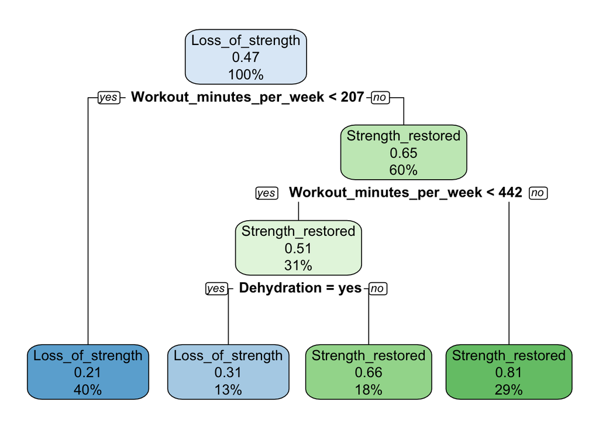

```r
model <- rpart(Outcome~., data=dataset_train, method = "class")

#pdf("tree.pdf")
rpart.plot(model, extra="auto", yesno=2)
```

```r
#dev.off()
```

## Making a prediction using the test dataset

```r
make_prediction <- predict(model, dataset_test, type="class")

# create table
tab <- table(dataset_test$Outcome, make_prediction)
tab
```

```
##                    make_prediction
##                     Loss_of_strength Strength_restored
##   Loss_of_strength               910               259
##   Strength_restored              275               789
```

## Measuring performance

We can use the confusion matrix to evaluate the performance by counting the number of times TRUE instances are classified as FALSE.

```r
accuracy <- sum(diag(tab)) / sum(tab)
print(paste("Accuracy", accuracy))
```

```
## [1] "Accuracy 0.760859829825347"
```

Accuracy is 76% for the test dataset.